# Analisis Exploratorio

Mariana

2023-02-02

## Analisis Exploratorio

### Carga de movies

Guardaremos los movies en un objeto llamado movies

```r
movies <- read.csv("movies.csv")
```

## Ejercicio 4.5

¿Cuántas películas se hicieron en cada año? ¿En qué año se hicieron más peñículas? Haga un gráfico de barras ¿Cuántas películas se hicieron en cada año? ¿En qué año se hicieron más películas? Haga un gráfico de barras

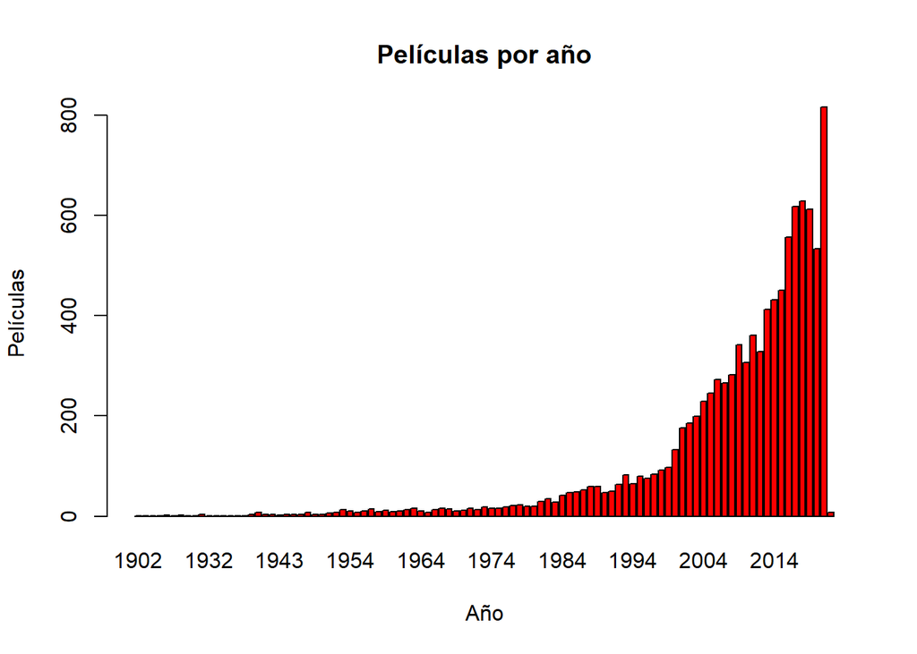

```r
movies$releaseDate <- as.Date(movies$releaseDate)
movies$year <- format(movies$releaseDate, "%Y")
movies$year <- as.numeric(movies$year)
movies$year <- as.factor(movies$year)
moviesByYear <- table(movies$year) # nolint
barplot(moviesByYear, main = "Películas por año", xlab = "Año", ylab = "Películas", col = "red") # nolint
```

## Ejercicio 4.6

¿Cuál es el género principal de las 20 peliculas más recientes? ¿Cuál es el género principal que predomina en el conjunto de movies? Represéntelo usando un gráfico.

```r
popularMovie <- movies[order(movies$popularity,decreasing = TRUE),]
top20 <- popularMovie[1:20,c("genres")]
genres20 <- unlist(strsplit(as.character(top20), "\\|"))
genres20
```

```
##  [1] "Action"          "Adventure"       "Fantasy"         "Science Fiction"
##  [5] "Action"          "Adventure"       "Science Fiction" "Animation"
##  [9] "Comedy"          "Family"          "Music"           "Horror"
## [13] "Action"          "Science Fiction" "Animation"       "Comedy"
## [17] "Family"          "Fantasy"         "Comedy"          "Fantasy"
## [21] "Adventure"       "Action"          "Thriller"        "Science Fiction"
## [25] "Action"          "Adventure"       "Science Fiction" "Action"
## [29] "Adventure"       "Science Fiction" "Thriller"        "Action"
## [33] "Thriller"        "Action"          "Comedy"          "Crime"
## [37] "Thriller"        "Action"          "Adventure"       "Fantasy"
## [41] "Action"          "Thriller"        "Crime"           "Drama"
## [45] "Horror"          "Mystery"         "Animation"       "Comedy"
## [49] "Family"          "Crime"           "Action"          "Thriller"
## [53] "Animation"       "Action"          "Adventure"       "Fantasy"
## [57] "Drama"           "History"         "Adventure"       "Horror"
## [61] "Thriller"
```

```r
#Ordenando
getmode <- function(v) {
  uniqv <- unique(v)
  uniqv[which.max(tabulate(match(v, uniqv)))]
}

top20 <- getmode(genres20)
top20
```

```
## [1] "Action"
```

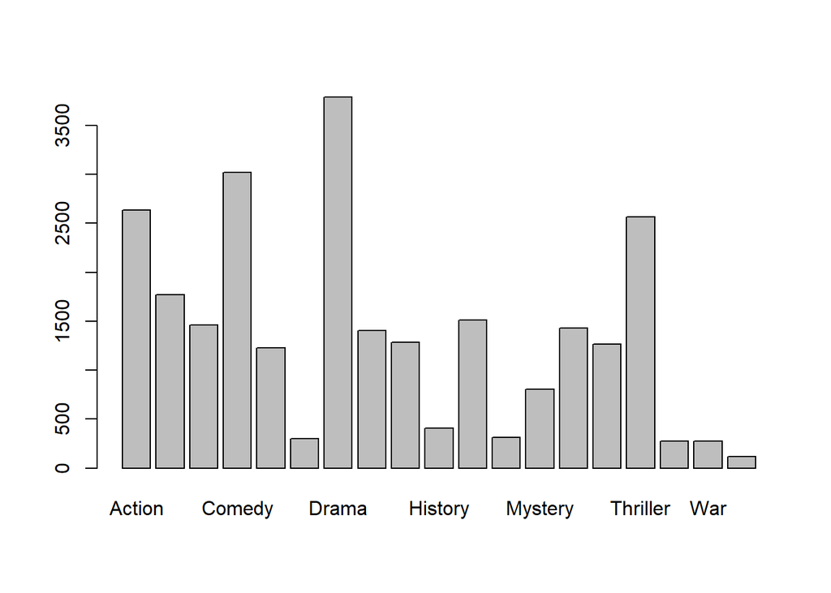

```r
#Graficando
total <- unlist(strsplit(as.character(movies$genres), "\\|"))
barplot(table(total))
```

## Ejercicio 4.7

¿Las películas de qué genero principal obtuvieron mayores ganancias?

```r
movies <- read.csv("movies.csv")
sum_by_genre <- aggregate(movies$revenue, by=list(movies$genres), sum)
genre_with_max_earnings <- sum_by_genre[which.max(sum_by_genre$x), ]
genre_with_max_earnings
```

```
##                             Group.1           x
## 94 Action|Adventure|Science Fiction 19780390887
```

## Ejercicio 4.8

¿La cantidad de actores influye en los ingresos de las películas?

```r
cor(movies$actorsAmount, movies$revenue)
```

```
## [1] -0.01955488
```

¿se han hecho películas con más actores en los últimos años?

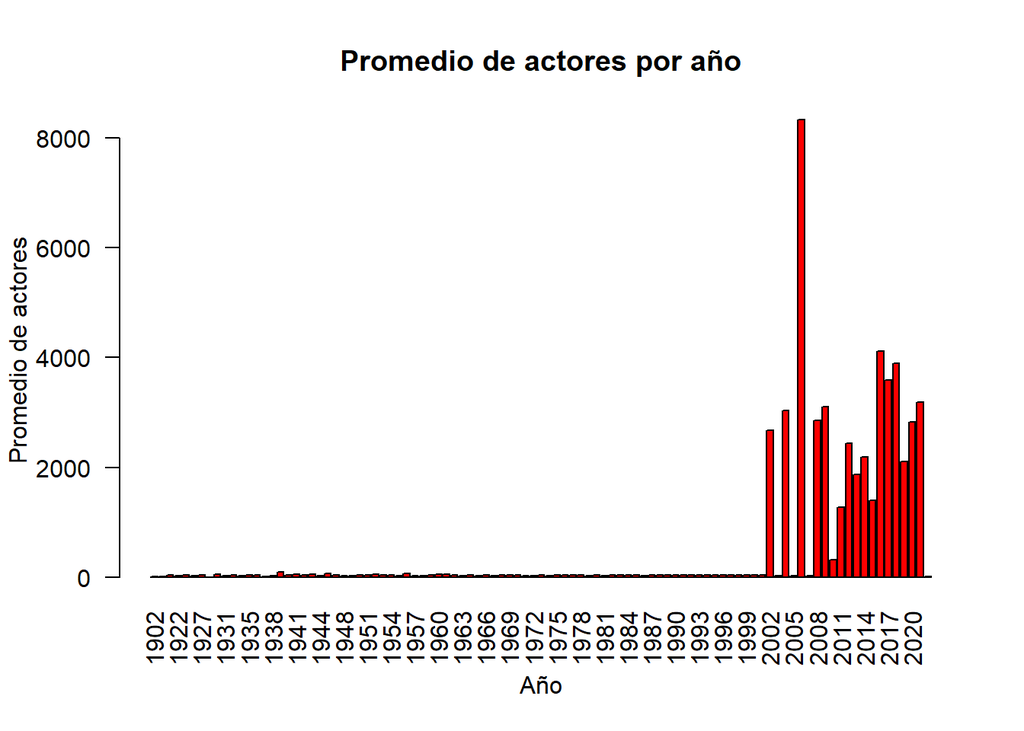

```r
movies$releaseDate <- as.Date(movies$releaseDate)
movies$year <- format(movies$releaseDate, "%Y")
movies$year <- as.numeric(movies$year)
movies$year <- as.factor(movies$year)
actorsByYear <- data.frame(movies$year, movies$actorsAmount)
actorsByYear <- aggregate(actorsByYear$movies.actorsAmount, by = list(actorsByYear$movies.year), FUN = mean)
barplot(actorsByYear$x, main = "Promedio de actores por año", xlab = "Año", ylab = "Promedio de actores", col = "red", las = 2, names.arg = actorsByYear$Group.1)
```

## Ejercicio 4.9

¿Es posible que la cantidad de hombres y mujeres en el reparto influya en la popularidad y los ingresos de las películas?

```r
cor(movies$actorsAmount, movies$popularity)
```

```
## [1] -0.006230412
```

```r
cor(movies$actorsAmount, movies$revenue)
```

```
## [1] -0.01955488
```

## Ejercicio 4.10

¿Quiénes son los directores que hicieron las 20 películas mejor calificadas?

```r
movies_without_na <- movies[!is.na(movies$voteCount) & is.numeric(movies$voteCount), ] # nolint: line_length_linter.
movies_sorted <- movies_without_na[order(movies_without_na$voteCount, decreasing = TRUE), ] # nolint: line_length_linter.
top_20_movies <- movies_sorted[1:20, ]
top_20_directors <- unique(top_20_movies$director)
top_20_directors
```

```
##  [1] "Christopher Nolan"              "Joss Whedon"
##  [3] "Tim Miller"                     "James Cameron"
##  [5] "James Gunn"                     "Anthony Russo|Joe Russo"
##  [7] "David Fincher"                  "Quentin Tarantino"
##  [9] "Jon Favreau"                    "Robert Zemeckis"
## [11] "Chris Columbus"                 "Lilly Wachowski|Lana Wachowski"
## [13] "Frank Darabont"                 "Peter Jackson"
## [15] "Todd Phillips"
```

## Ejercicio 4.11

¿Cómo se correlacionan los presupuestos con los ingresos? ¿Los altos presupuestos significan altos ingresos? Haga los gráficos que necesite, histograma, diagrama de dispersión?

```r
movies <- read.csv("movies.csv")
cor(movies$revenue, movies$budget)
```

```
## [1] 0.757454
```

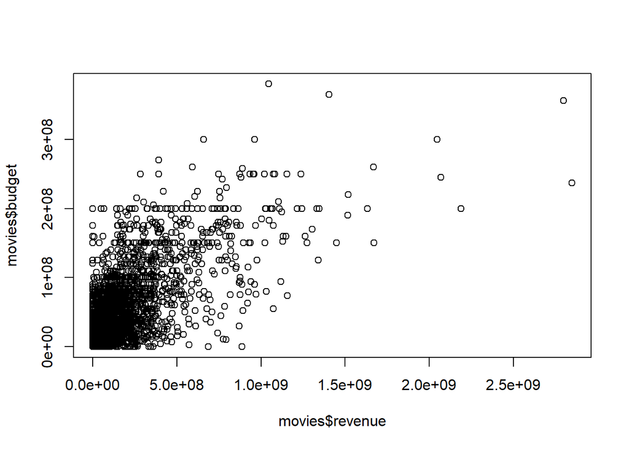

```r
# Graficando
plot(movies$revenue, movies$budget)
```

## Preguntas extra

¿Cuales son las 3 peliculas que han tenido menos ganancias?

```r
movies[order(movies$revenue), c("revenue", "title")][1:3, ]
```

```
##    revenue               title
## 26       0              Brazil
## 57       0  Three Colors: Blue
## 58       0 Three Colors: White
```

¿Cuál es la pelicula que cuenta con mas cantidad de actores hombres?

```r
movies$castMenAmount <- suppressWarnings(as.numeric(movies$castMenAmount))
movies[order(movies$castMenAmount, decreasing = TRUE), c("castMenAmount", "title")][1, ] # nolint: line_length_linter.
```

```
##      castMenAmount                          title
## 9998        922017 Chief Daddy 2: Going for Broke
```